# 607 Project

## New Comers

I was interested in two coins that are currently valued really low, Ripple and Tether. I was able to find the historical data on https://coinmarketcap.com. Since I couldn’t download it, I decided to scrape the data.

```r
Rip <- read_html("https://coinmarketcap.com/currencies/ripple/historical-data/?start=20130428&end=20171209")
Tet <- read_html("https://coinmarketcap.com/currencies/tether/historical-data/?start=20130428&end=20171209")
```

```r
Ripp <- html_text(html_nodes(Rip, "td"))
Rippl <- matrix(Ripp, ncol = 7, byrow = TRUE)
```

```r
Ripple <- data.frame(Rippl[2:1588,], stringsAsFactors = TRUE)
colnames(Ripple) <- c("Date","Open","High","Low","Close","Volume","Market Cap")
head(Ripple)
```

```
##           Date     Open     High      Low    Close      Volume
## 1 Dec 08, 2017 0.223636 0.278673 0.222168 0.252125 660,172,000
## 2 Dec 07, 2017 0.232623 0.233760 0.221340 0.222823 275,205,000
## 3 Dec 06, 2017 0.245416 0.245705 0.227742 0.232544 274,526,000
## 4 Dec 05, 2017 0.253598 0.253988 0.245234 0.246101 174,591,000
## 5 Dec 04, 2017 0.252919 0.255362 0.247160 0.253571 104,650,000
## 6 Dec 03, 2017 0.255530 0.263072 0.247391 0.252558 134,710,000
##      Market Cap
## 1 8,663,460,000
## 2 9,011,630,000
## 3 9,507,190,000
## 4 9,815,990,000
## 5 9,768,480,000
## 6 9,869,310,000
```

```r
Teth <- html_text(html_nodes(Tet, "td"))
Tethe <- matrix(Teth, ncol = 7, byrow = TRUE)
```

```r
Tether <- data.frame(Tethe[2:1013,], stringsAsFactors = TRUE)
colnames(Tether) <- c("Date","Open","High","Low","Close","Volume","Market Cap")
head(Tether)
```

```
##           Date     Open High      Low Close        Volume  Market Cap
## 1 Dec 08, 2017     1.04 1.06 0.986563  1.02 1,993,030,000 843,587,000
## 2 Dec 07, 2017     1.01 1.08     1.00  1.03 1,671,610,000 819,775,000
## 3 Dec 06, 2017 0.999760 1.02 0.995840  1.01 1,281,490,000 813,822,000
## 4 Dec 05, 2017     1.00 1.01 0.996458  1.00   814,146,000 816,872,000
## 5 Dec 04, 2017     1.00 1.01 0.992132  1.00   668,510,000 816,012,000
## 6 Dec 03, 2017     1.00 1.03 0.985320  1.00   946,749,000 814,847,000
```

# Cleaning the data

I want all the to be in the same format as the Bitcoin API. For the CSV files, I first wanted to reorder the data since it starts from the earliest point.

```r
Bc_cash <-Bc_cash[130:1,]
Dash <-Dash[1393:1,]
Ethereum <-Ethereum[854:1,]
Litecoin <-Litecoin[1685:1,]
```

The Bitcoin API is in a YYYY-MM-DD format. So I needed to change that all the dates to that format.

```r
Bc_cash$date <- as.Date(Bc_cash$date, format = "%m/%d/%Y")
Ethereum$date <- as.Date(Ethereum$date, format = "%m/%d/%Y")
Dash$date <- as.Date(Dash$date, format = "%m/%d/%Y")
Litecoin$date <- as.Date(Litecoin$date, format = "%m/%d/%Y")
```

Change column name ‘date’ to ‘Date’

```r
colnames(Bc_cash)[1] <- "Date"
colnames(Ethereum)[1] <- "Date"
colnames(Dash)[1] <- "Date"
colnames(Litecoin)[1] <- "Date"
```

Since the two scraped data is from a html website, all of it needs to be reformatted.

```r
Tether[,2:5] %<>%
      mutate_each(funs(if(is.factor(.)) as.character(.) else .)) %<>%
       mutate_each(funs(if(is.character(.)) as.numeric(.) else .))
Ripple[,2:5] %<>%
      mutate_each(funs(if(is.factor(.)) as.character(.) else .)) %<>%
       mutate_each(funs(if(is.character(.)) as.numeric(.) else .))
```

Also, change the date format to YYYY-MM-DD format.

```r
Tether$Date <- as.Date(Tether$Date, format = "%b %d, %Y")
Ripple$Date <- as.Date(Ripple$Date, format = "%b %d, %Y")
```

# Combining the data

Now that all of our data is in consistent format, lets get all the variables needed for analysis.

I want to average out the highs and lows to get one price for the day.

```r
require(magrittr)
Bitcoin %<>% mutate(bitcoin_price = (High + Low)/2,
                bitcoin_gain = Close - Open)
Ripple %<>% mutate(ripple_price = (High + Low)/2,
                ripple_gain  = Close - Open)
Tether %<>% mutate(tether_price = (High + Low)/2,
                tether_gain =  Close - Open)
```

Selecting the data we need.

```r
Bitcoin_data <- select(Bitcoin, Date,bitcoin_price)
Ripple_data <- select(Ripple, Date, ripple_price)
Tether_data <- select(Tether, Date, tether_price)
Ethereum_data <- select(Ethereum, Date, price.USD.)
Dash_data <- select(Dash, Date, price.USD.)
Bc_cash_data <- select(Bc_cash, Date, price.USD.)
Litecoin_data <- select(Litecoin, Date, price.USD.)
```

Since, all of our data is in the same format, we join them using the ‘Date’ field as the identifier. Bitcoin data has the most rows, so I used it as the left part of left join.

```r
cryptocurrencies <-
left_join(
left_join(
left_join(
left_join(
  left_join(
    left_join(Bitcoin_data, Ripple_data, "Date"),
    Tether_data, "Date"),
    Ethereum_data, "Date"),
    Dash_data, "Date"),
    Bc_cash_data, "Date"),
    Litecoin_data, "Date")
colnames(cryptocurrencies) <- c("Date","bitcoin_price","ripple_price","tether_price",
                                 "ethereum_price", "dash_price","bc_cash_price","litecoin_price")
head(cryptocurrencies)
```

```
##         Date bitcoin_price ripple_price tether_price ethereum_price
## 1 2017-12-07      14850.76    0.2275500     1.040000         434.41
## 2 2017-12-06      12679.90    0.2367235     1.007920         428.59
## 3 2017-12-05      11617.12    0.2496110     1.003229         463.28
## 4 2017-12-04      11231.53    0.2512610     1.001066         470.20
## 5 2017-12-03      11156.58    0.2552315     1.007660         465.85
## 6 2017-12-02      10918.85    0.2549870     1.007805         463.45
##   dash_price bc_cash_price litecoin_price
## 1     697.90       1330.93          98.29
## 2     700.07       1430.10         100.35
## 3     756.36       1501.85         102.40
## 4     774.01       1576.92         104.24
## 5     768.88       1559.93         101.26
## 6     778.43       1434.98         100.28
```

Since the prices of the currencies between each other have huge differences, it would be hard to compare them. I decided to calculate the relative change between them.

I created another table with the previous day’s price, added 1 to the day and did a left join to match the day.

```r
Prior_day <- cryptocurrencies[2:2278,]
Prior_day$Date <- as.Date(Prior_day$Date)+1
colnames(Prior_day) <- c("Date","yes_bitcoin_price","yes_ripple_price","yes_tether_price",
                                 "yes_ethereum_price", "yes_dash_price","yes_bc_cash_price","yes_litecoin_price")

r_cyptocurrencies <- left_join(cryptocurrencies, Prior_day, by ="Date")
r_cyptocurrencies <- select(r_cyptocurrencies, Date, bitcoin_price, yes_bitcoin_price, ripple_price, yes_ripple_price, tether_price, yes_tether_price,
                            ethereum_price, yes_ethereum_price, dash_price, yes_dash_price, bc_cash_price, yes_bc_cash_price, litecoin_price, yes_litecoin_price)
head(r_cyptocurrencies)
```

```
##         Date bitcoin_price yes_bitcoin_price ripple_price yes_ripple_price
## 1 2017-12-07      14850.76          12679.90    0.2275500        0.2367235
## 2 2017-12-06      12679.90          11617.12    0.2367235        0.2496110
## 3 2017-12-05      11617.12          11231.53    0.2496110        0.2512610
## 4 2017-12-04      11231.53          11156.58    0.2512610        0.2552315
## 5 2017-12-03      11156.58          10918.85    0.2552315        0.2549870
## 6 2017-12-02      10918.85          10160.00    0.2549870        0.2491330
##   tether_price yes_tether_price ethereum_price yes_ethereum_price
## 1     1.040000         1.007920         434.41             428.59
## 2     1.007920         1.003229         428.59             463.28
## 3     1.003229         1.001066         463.28             470.20
## 4     1.001066         1.007660         470.20             465.85
## 5     1.007660         1.007805         465.85             463.45
## 6     1.007805         1.006522         463.45             466.54
##   dash_price yes_dash_price bc_cash_price yes_bc_cash_price litecoin_price
## 1     697.90         700.07       1330.93           1430.10          98.29
## 2     700.07         756.36       1430.10           1501.85         100.35
## 3     756.36         774.01       1501.85           1576.92         102.40
## 4     774.01         768.88       1576.92           1559.93         104.24
## 5     768.88         778.43       1559.93           1434.98         101.26
## 6     778.43         797.53       1434.98           1462.68         100.28
##   yes_litecoin_price
## 1             100.35
## 2             102.40
## 3             104.24
## 4             101.26
## 5             100.28
## 6              99.00
```

Calculate relative change

```r
r_cyptocurrencies %<>% mutate(bitcoin_change = ((bitcoin_price - yes_bitcoin_price)/yes_bitcoin_price)*100,
                              ripple_change =  ((ripple_price - yes_ripple_price)/yes_ripple_price)*100,
                              tether_change =  ((tether_price - yes_tether_price)/yes_tether_price)*100,
                              ethereum_change =  ((ethereum_price - yes_ethereum_price)/yes_ethereum_price)*100,
                              dash_change =  ((dash_price - yes_dash_price)/yes_dash_price)*100,
                              bc_cash_change =  ((bc_cash_price - yes_bc_cash_price)/yes_bc_cash_price)*100,
                              litecoin_change =  ((litecoin_price - yes_litecoin_price)/yes_litecoin_price)*100)
```

Create a new table with just the relative changes.

```r
relative_change <- select(r_cyptocurrencies, "Date", ends_with("change"))
relative_change_ <- relative_change

relative_change_[is.na(relative_change_ <- relative_change)] <- 0
head(relative_change_)
```

```
##         Date bitcoin_change ripple_change tether_change ethereum_change
## 1 2017-12-07     17.1204820   -3.87519617    3.18279229       1.3579412
## 2 2017-12-06      9.1483478   -5.16303368    0.46759015      -7.4879123
## 3 2017-12-05      3.4331015   -0.65668767    0.21606967      -1.4717142
## 4 2017-12-04      0.6718006   -1.55564654   -0.65438739       0.9337770
## 5 2017-12-03      2.1773365    0.09588724   -0.01443731       0.5178552
## 6 2017-12-02      7.4689469    2.34974893    0.12756806      -0.6623226
##   dash_change bc_cash_change litecoin_change
## 1  -0.3099690      -6.934480      -2.0528151
## 2  -7.4422233      -4.777441      -2.0019531
## 3  -2.2803323      -4.760546      -1.7651573
## 4   0.6672042       1.089151       2.9429192
## 5  -1.2268284       8.707438       0.9772637
## 6  -2.3948942      -1.893784       1.2929293
```

Round the percentages

```r
relative_change_$bitcoin_change <- round(relative_change_$bitcoin_change, 4)
relative_change_$ripple_change <- round(relative_change_$ripple_change ,4)
relative_change_$tether_change <- round(relative_change_$tether_change ,4)
relative_change_$ethereum_change <- round(relative_change_$ethereum_change ,4)
relative_change_$dash_change <- round(relative_change_$dash_change ,4)
relative_change_$bc_cash_change <- round(relative_change_$bc_cash_change ,4)
relative_change_$litecoin_change <- round(relative_change_$litecoin_change ,4)
```

# Analysis

## Relative Change

Tidy the data for analysis. The mean relative change shows the average changes.

```r
tidy_change <- (gather(relative_change_, key= Currency, "relative_change", desc("Date")))
tidy_change %>% filter(relative_change !=0, is.finite(relative_change) == TRUE) %>%
  group_by(Currency) %>%  summarise(mean = mean(relative_change), count = n())
```

```
## # A tibble: 7 x 3
##          Currency        mean count
##             <chr>       <dbl> <int>
## 1  bc_cash_change  1.97931085   129
## 2  bitcoin_change -0.05745514  2249
## 3     dash_change  0.98085324  1360
## 4 ethereum_change  0.93719399   849
## 5 litecoin_change  0.44710412  1602
## 6   ripple_change  0.44249058  1581
## 7   tether_change  0.02202607   399
```

From the data, we can see that Bitcoin prices has a negative relative change. This might be due to some skews in our data. Lets limit high percentage changes.

```r
tidy_change <- (gather(relative_change_, key= Currency, "relative_change", desc("Date")))
tidy_change %>% filter(relative_change !=0, is.finite(relative_change) == TRUE, relative_change < 50, relative_change > -50) %>%
  group_by(Currency) %>%  summarise(mean = mean(relative_change), count = n())
```

```
## # A tibble: 7 x 3
##          Currency       mean count
##             <chr>      <dbl> <int>
## 1  bc_cash_change 1.16503465   127
## 2  bitcoin_change 0.41088594  2233
## 3     dash_change 0.57381055  1355
## 4 ethereum_change 0.90714835   846
## 5 litecoin_change 0.22708623  1598
## 6   ripple_change 0.29571635  1578
## 7   tether_change 0.02202607   399
```

We see that when we limit the relative changes between -50 and 50, there is significant changes to the mean, but not the count.

```r
tidy_change <- (gather(relative_change_, key= Currency, "relative_change", desc("Date")))
tidy_change %>% filter(relative_change !=0, is.finite(relative_change) == TRUE, relative_change < 10, relative_change > -10) %>%
  group_by(Currency) %>%  summarise(mean = mean(relative_change), count = n())
```

```
## # A tibble: 7 x 3
##          Currency        mean count
##             <chr>       <dbl> <int>
## 1  bc_cash_change -0.71430515    97
## 2  bitcoin_change  0.36466306  2152
## 3     dash_change -0.12132624  1189
## 4 ethereum_change -0.12964241   738
## 5 litecoin_change -0.08903114  1461
## 6   ripple_change -0.14734908  1465
## 7   tether_change  0.02202607   399
```

When we limit the relative change to between -10 and 10, most of the mean is negative. This means for 5/7 observations, the increases are due to high shifts in the market in the day, but most days, they are losing value. This is opposite for Bitcoin, which is increasing on most days and its losses come from large drops in the market. For Tether, the market looks surprisingly stable. This may be due to it being a small player in the market.

Let’s visualize the relative changes.

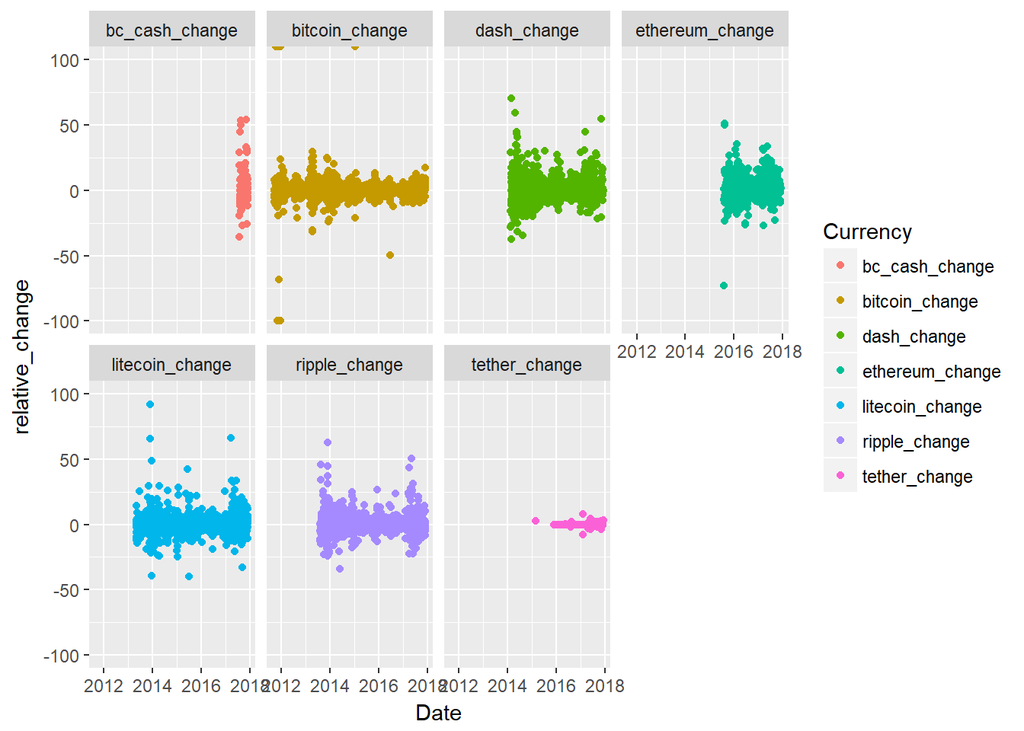

```r
ggplot(data =tidy_change[which(tidy_change$relative_change != 0),]) +
  geom_point(mapping = aes(x= Date, y= relative_change, color= Currency,fill = Currency), position = "jitter")+
  facet_wrap(~ Currency, nrow = 2)+
  ylim(-100,100)
```

From the visualization, we can see that the spread is very large for most of the currencies with exception to tether. Visualizing the relative changes together.

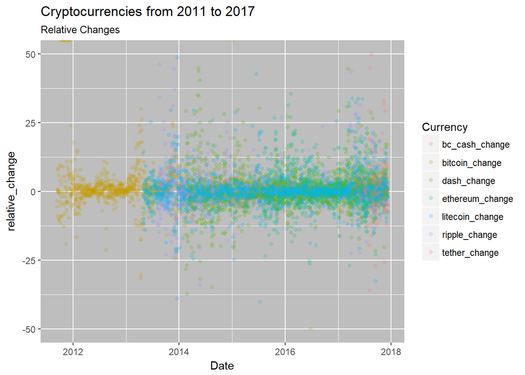

```r
ggplot(data =tidy_change[which(tidy_change$relative_change != 0),]) +
  geom_point(mapping = aes(x= Date, y= relative_change, color= Currency,fill = Currency),alpha = 1/5, position = "jitter") +
  ylim(-50,50)+
  theme(panel.background = element_rect(fill = 'gray'))+
  ggtitle("Cryptocurrencies from 2011 to 2017",subtitle = "Relative Changes")
```

## Gain to Loss Ratio

Let’s dive deeper into how the currencies fluctuate and look at gain to loss ratio. Categorize for each relative change percentage to ‘gain’, ‘loss’ or ‘no change’.

```r
tidy_change$lost_gain <- ifelse(tidy_change$relative_change > 0, "gain",
                                ifelse(tidy_change$relative_change ==0,"no,change","loss"))
tidy_change[sample(nrow(iris), 10), ]
```

```
##           Date       Currency relative_change lost_gain
## 21  2017-11-17 bitcoin_change          2.8340      gain
## 113 2017-08-17 bitcoin_change          4.1100      gain
## 51  2017-10-18 bitcoin_change         -4.9985      loss
## 121 2017-08-09 bitcoin_change         -2.7714      loss
## 44  2017-10-25 bitcoin_change         -1.8459      loss
## 6   2017-12-02 bitcoin_change          7.4689      gain
## 29  2017-11-09 bitcoin_change         -2.7847      loss
## 84  2017-09-15 bitcoin_change         -4.7636      loss
## 56  2017-10-13 bitcoin_change          9.6475      gain
## 122 2017-08-08 bitcoin_change          2.6300      gain
```

Untidy the data for analysis

```r
#All
ratio<- tidy_change %>% group_by(Currency) %>% count(lost_gain)
gain_loss_ratio <- ratio %<>% spread(lost_gain, n) %<>%   mutate(ratio = gain/loss)
gain_loss_ratio <- select(gain_loss_ratio,Currency,ratio)
#Limit -100 to 100
ratio100<- tidy_change %>% filter(relative_change < 100, relative_change > -100) %>% group_by(Currency) %>% count(lost_gain)
gain_loss_ratio100 <- ratio100 %<>% spread(lost_gain, n) %<>%   mutate(ratio100 = gain/loss)
gain_loss_ratio100 <- select(gain_loss_ratio100,Currency,ratio100)

#Limit -10 to 10
ratio1<- tidy_change %>% filter(relative_change < 10, relative_change > -10) %>% group_by(Currency) %>% count(lost_gain)
gain_loss_ratio1 <- ratio1 %<>% spread(lost_gain, n) %<>%   mutate(ratio10 = gain/loss)
gain_loss_ratio1 <- select(gain_loss_ratio1,Currency,ratio10)
```

```r
All_ratios <- inner_join(gain_loss_ratio,inner_join(gain_loss_ratio100,gain_loss_ratio1,by = "Currency"),by= "Currency")
All_ratios$Currency <- c("Bitcoin Cash", "Bitcoin", "Dash", "Ethereum","Litecoin","Ripple","Tether")
All_ratios
```

```
## # A tibble: 7 x 4
## # Groups:   Currency [?]
##       Currency     ratio  ratio100   ratio10
##          <chr>     <dbl>     <dbl>     <dbl>
## 1 Bitcoin Cash 0.8970588 0.8970588 0.7017544
## 2      Bitcoin 1.2507463 1.2520161 1.2510460
## 3         Dash 0.9209040 0.9180791 0.8405573
## 4     Ethereum 0.9698376 0.9698376 0.8403990
## 5     Litecoin 0.9418182 0.9406061 0.9023438
## 6       Ripple 0.8843862 0.8831943 0.8381430
## 7       Tether 1.1336898 1.1336898 1.1336898
```

Lets visualize the results.

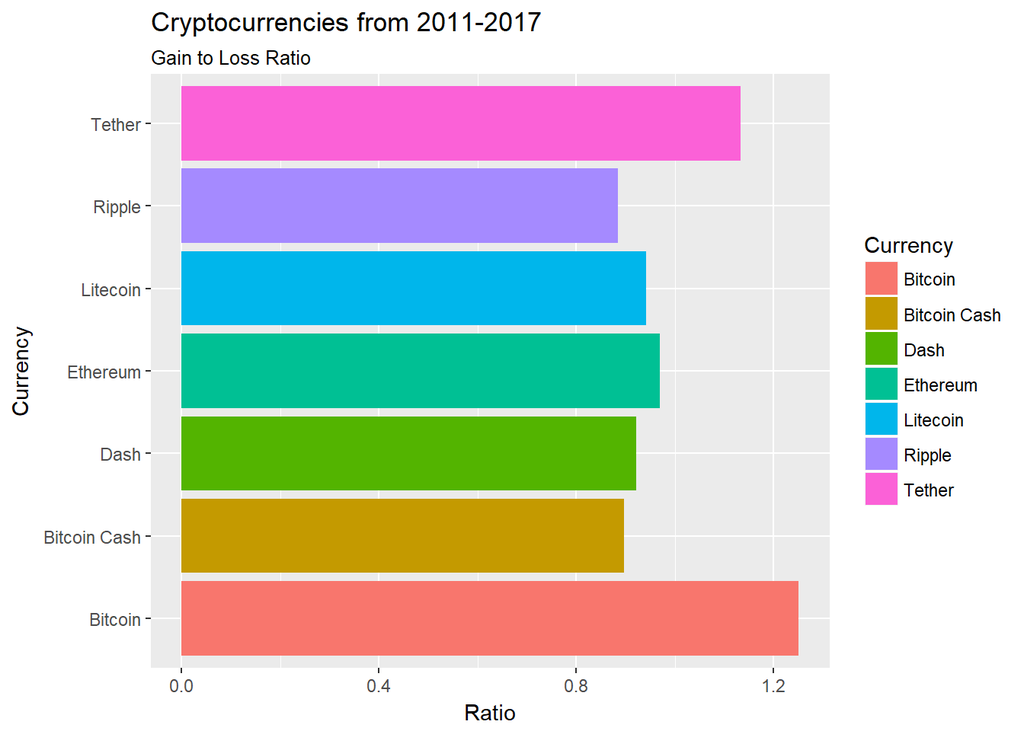

```r
ratio_bar <- ggplot(All_ratios, mapping = aes(y= ratio,x= Currency, fill=Currency))  +
  geom_bar(stat = "identity") +
  ggtitle("Cryptocurrencies from 2011-2017", subtitle = "Gain to Loss Ratio")+
  labs(y= "Ratio")
ratio_bar + coord_flip()
```

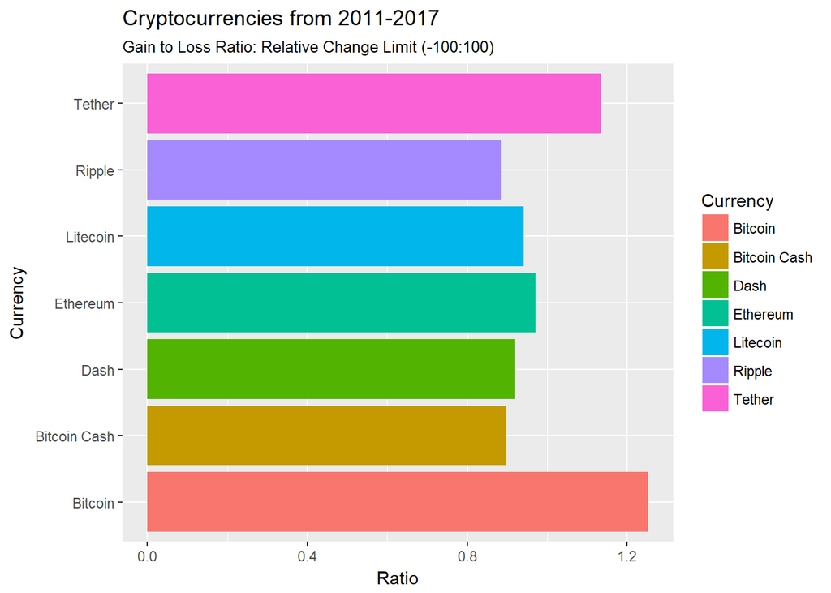

```r
ratio_bar100 <- ggplot(All_ratios, mapping = aes(y= ratio100,x= Currency, fill=Currency))  +
  geom_bar(stat = "identity") +
  ggtitle("Cryptocurrencies from 2011-2017", subtitle = "Gain to Loss Ratio: Relative Change Limit (-100:100)")+
  labs(y= "Ratio")
ratio_bar100 + coord_flip()
```

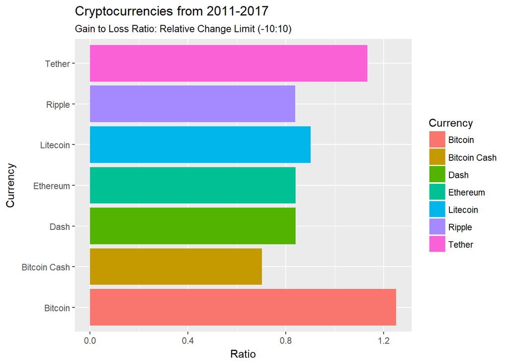

```r
ratio_bar1 <- ggplot(All_ratios, mapping = aes(y= ratio10,x= Currency, fill=Currency))+
  geom_bar(stat = "identity") +
  ggtitle("Cryptocurrencies from 2011-2017", subtitle = "Gain to Loss Ratio: Relative Change Limit (-10:10)")+
  labs(y= "Ratio")
ratio_bar1 + coord_flip()
```

When we compare the overall gains to losses, we can see that there is a significant drop for Ripple, Litecoin, Ethereum, Dash and Bitcoin cash.

## Probability

Lets look at the probability of currencies increasing on a given day, based on the count of gains and losses.

```r
gain_loss_counts <- tidy_change %>% group_by(Currency, lost_gain) %>% summarise(n=n())
gain_loss_counts <- spread(gain_loss_counts, lost_gain, n)
gain_loss_counts <- mutate(gain_loss_counts, probability = (gain/(gain+loss)))
probability <- select(gain_loss_counts, Currency, probability)

gain_loss_counts100 <- tidy_change %>% filter(relative_change < 100, relative_change > -100) %>%
                      group_by(Currency, lost_gain) %>% summarise(n=n())
gain_loss_counts100 <- spread(gain_loss_counts100, lost_gain, n)
gain_loss_counts100 <- mutate(gain_loss_counts100, probability100 = (gain/(gain+loss)))
probability100 <- select(gain_loss_counts100, Currency, probability100)

gain_loss_counts10 <- tidy_change %>% filter(relative_change < 10, relative_change > -10) %>%
             group_by(Currency, lost_gain) %>% summarise(n=n())
gain_loss_counts10 <- spread(gain_loss_counts10, lost_gain, n)
gain_loss_counts10 <- mutate(gain_loss_counts10, probability10 = (gain/(gain+loss)))
probability10 <- select(gain_loss_counts10, Currency, probability10)

All_probability <- inner_join(probability,inner_join(probability100,probability10,by = "Currency"),by= "Currency")
All_probability$Currency <- c("Bitcoin Cash", "Bitcoin", "Dash", "Ethereum","Litecoin","Ripple","Tether")
All_probability
```

```
## # A tibble: 7 x 4
## # Groups:   Currency [?]
##       Currency probability probability100 probability10
##          <chr>       <dbl>          <dbl>         <dbl>
## 1 Bitcoin Cash   0.4728682      0.4728682     0.4123711
## 2      Bitcoin   0.5557029      0.5559534     0.5557621
## 3         Dash   0.4794118      0.4786451     0.4566863
## 4     Ethereum   0.4923439      0.4923439     0.4566396
## 5     Litecoin   0.4850187      0.4846971     0.4743326
## 6       Ripple   0.4693232      0.4689873     0.4559727
## 7       Tether   0.5313283      0.5313283     0.5313283
```

The probability table shows that Bitcoin has the highest chance of increase on a given day with 55% and that stays consistent when outliers are removed. Second is Tether with 53%. The rest is in the 47%-49% range, but decreases when outliers are removed. out of the remaining 5, Litecoin is most consistent, dropping from 48.5% to 47.4%.

Lets visualize the results.

```r
facet_wrap(~All_ratios,nrow = 3)
```

[output not shown]

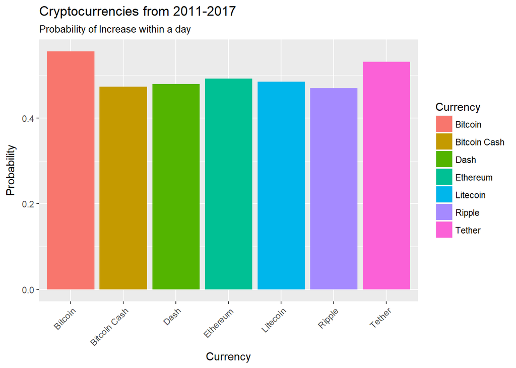

```r
probability_bar <- ggplot(All_probability, mapping = aes(y=probability,x= Currency, fill=Currency))  +
  geom_bar(stat = "identity") +
  ggtitle("Cryptocurrencies from 2011-2017", subtitle = "Probability of Increase within a day")+
  labs(y= "Probability") +
  theme(axis.text.x = element_text(angle = 45, hjust = 1))

probability_bar
```

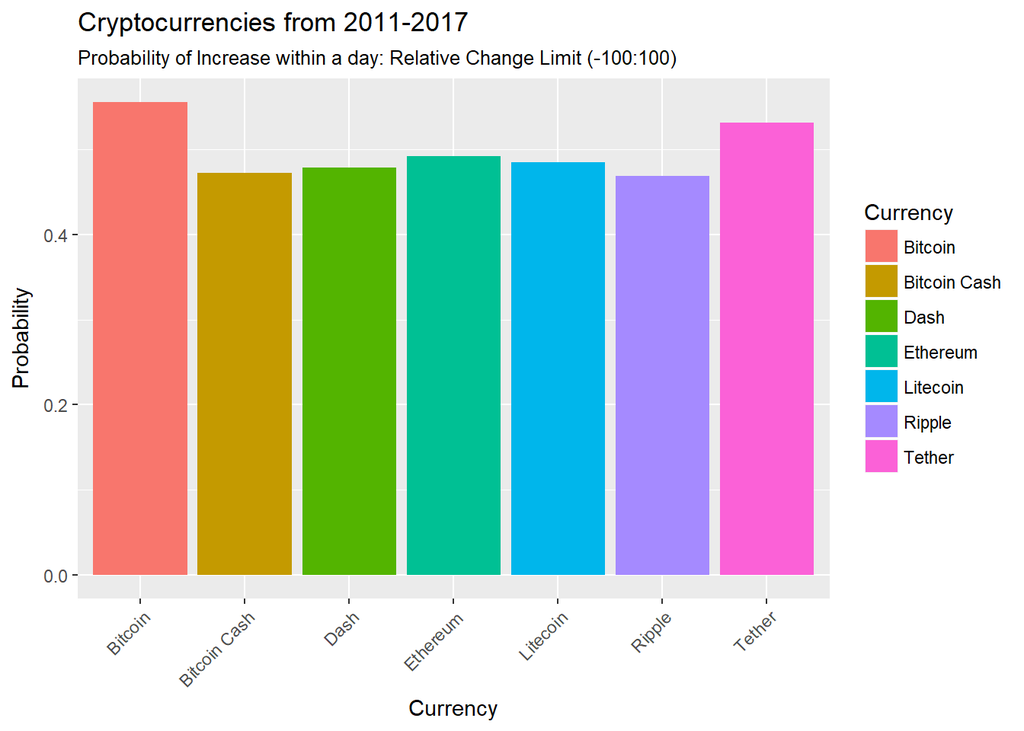

```r
probability_bar100 <- ggplot(All_probability, mapping = aes(y= probability100,x= Currency, fill=Currency))  +
  geom_bar(stat = "identity") +
  ggtitle("Cryptocurrencies from 2011-2017", subtitle = "Probability of Increase within a day: Relative Change Limit (-100:100)")+
  labs(y= "Probability") +
    theme(axis.text.x = element_text(angle = 45, hjust = 1))
probability_bar100
```

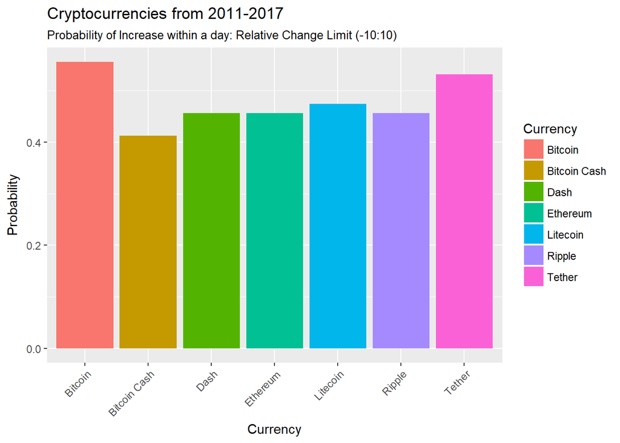

```r
probability_bar1 <- ggplot(All_probability, mapping = aes(y=probability10,x= Currency, fill=Currency))+
  geom_bar(stat = "identity") +
  ggtitle("Cryptocurrencies from 2011-2017", subtitle = "Probability of Increase within a day: Relative Change Limit (-10:10)")+
  labs(y= "Probability")+
  theme(axis.text.x = element_text(angle = 45, hjust = 1))
probability_bar1
```

# Conclusion

When we looked at the gain to loss ratio, Bitcoin and Tether had a surplus in increases over losses, while the other 5 had a ratio of below 1. This supports the previous conclusion that there are more gains than losses and when we look at probabilities of this. We see that Bitcoin and Tether have a chance of increase more than 50% in a given day.

Overall, since the market moves so fast, a day to day analysis might not be enough to come up with an accurate assumption.